# Data Exploration

Jay

June 10, 2016

# Corrplot

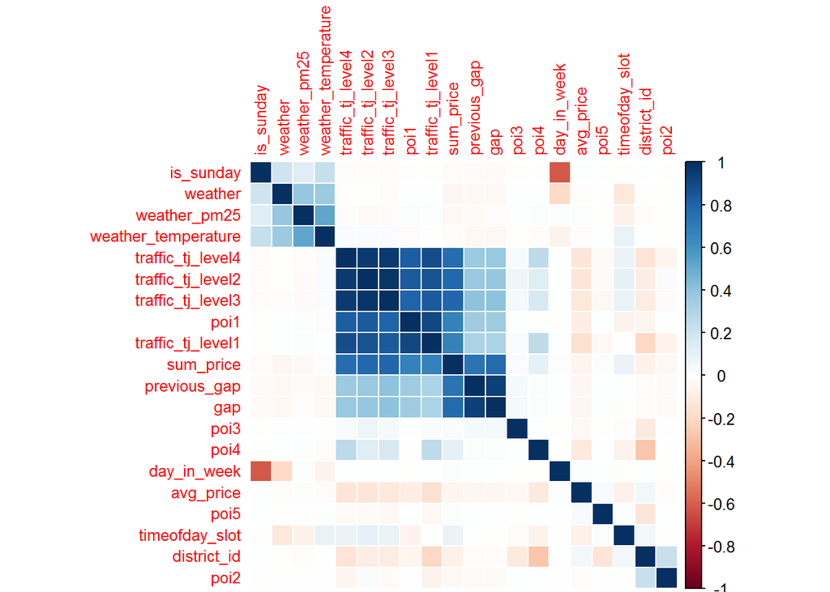

Clearer version is available at file `corrplot.png` (4000px width).

# Which days in week have different gaps?

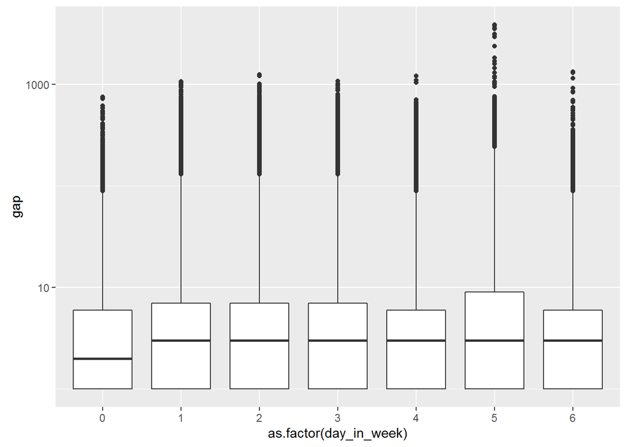

Looks like there are usually less gaps on Sunday. Variable `is_sunday` may need to be created.

```
## [1] "correlation between is_sunday and gap:  -0.0296602524007851"
```

```
## [1] "correlation between sum_price and gap:  0.770919932803114"
```

```
## [1] "correlation between poi1 and gap:  0.354326550872759"
```

# Get ordered correlation

Useful for feature selection step.

```
## [1] "gap, previous_gap, sum_price, traffic_tj_level3, traffic_tj_level2, traffic_tj_level4, poi1, traffic_tj_level1"
```

# Traffic

How do gaps differ on different traffic levels?

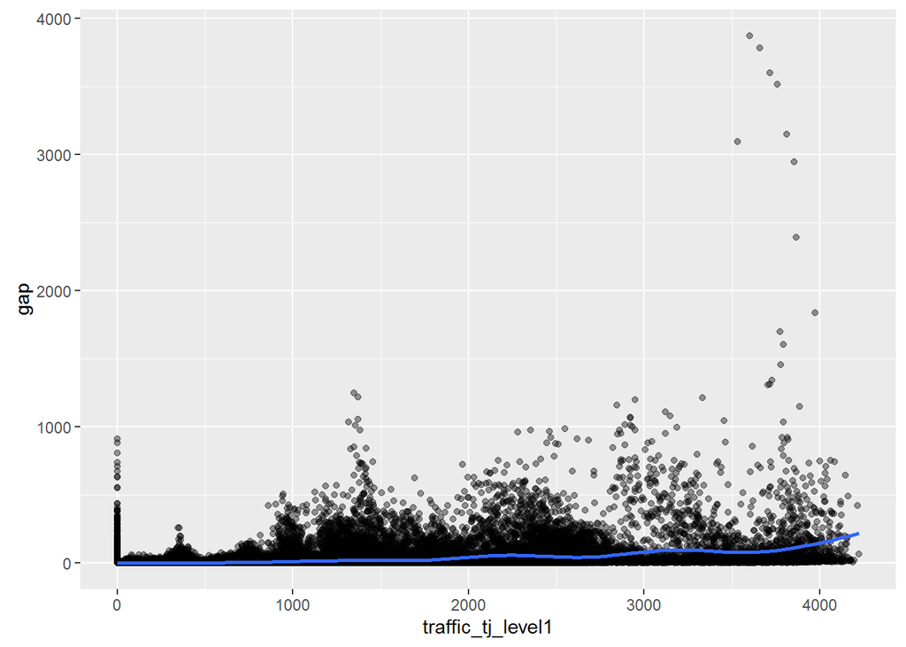

After 3500 `traffic_tj_level1` some high gaps are starting to show, but their numbers are insignificant compared to the entire general trend.

Let’s see if log scaling `gap` variable will unravel more information.

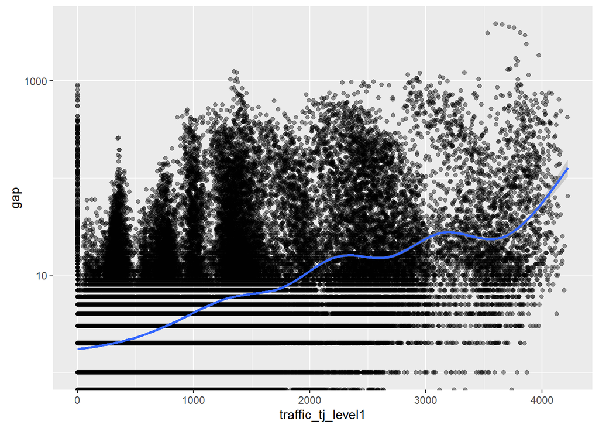

# Previous slot’s gap

Maybe previous slot’s gap affects next gap, since they are only separated by 10 minutes. Let’s explore this.

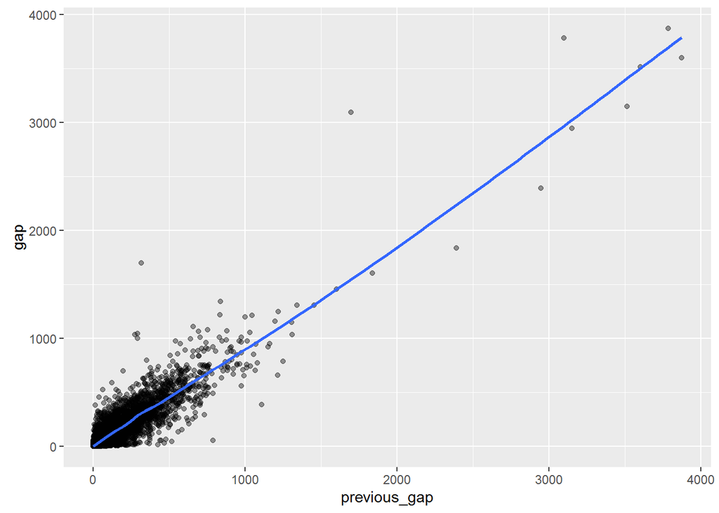

Bingo! `gap` and `previous_gap` are highly correlated it seems.

# Weather

Weather data have really low correlation with `gap`, but I wonder if there are some hidden structures we can find here.

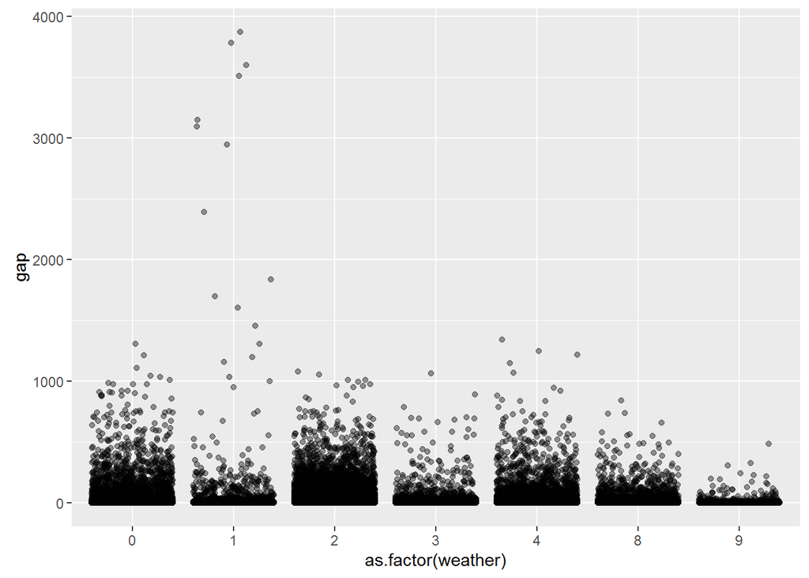

It looks like weather 1 has several high gaps.

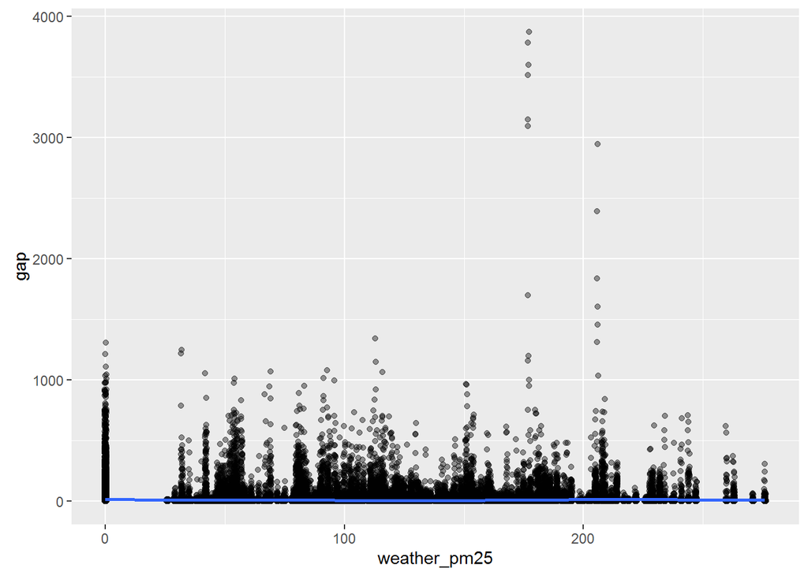

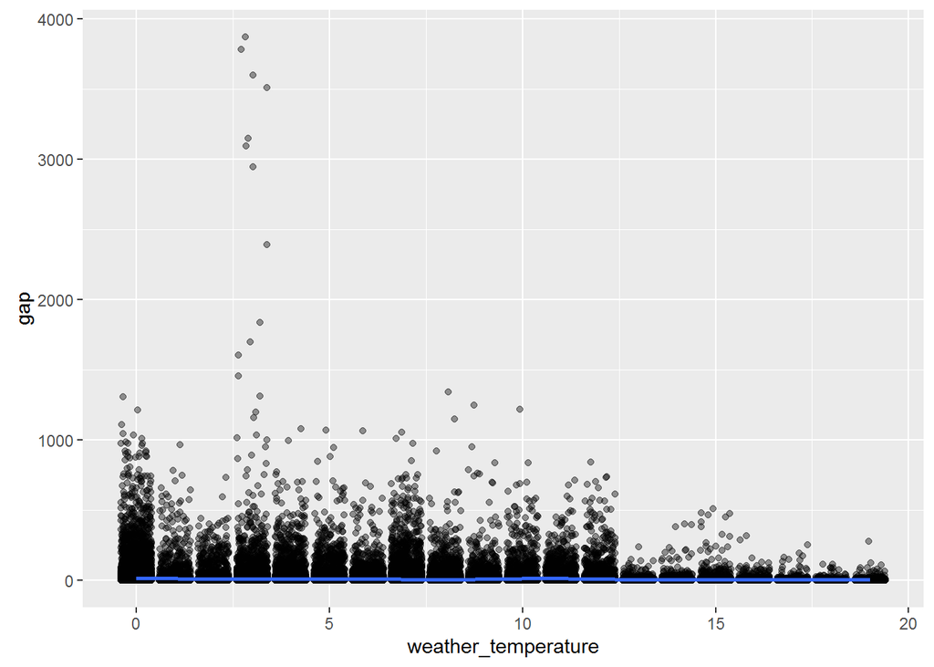

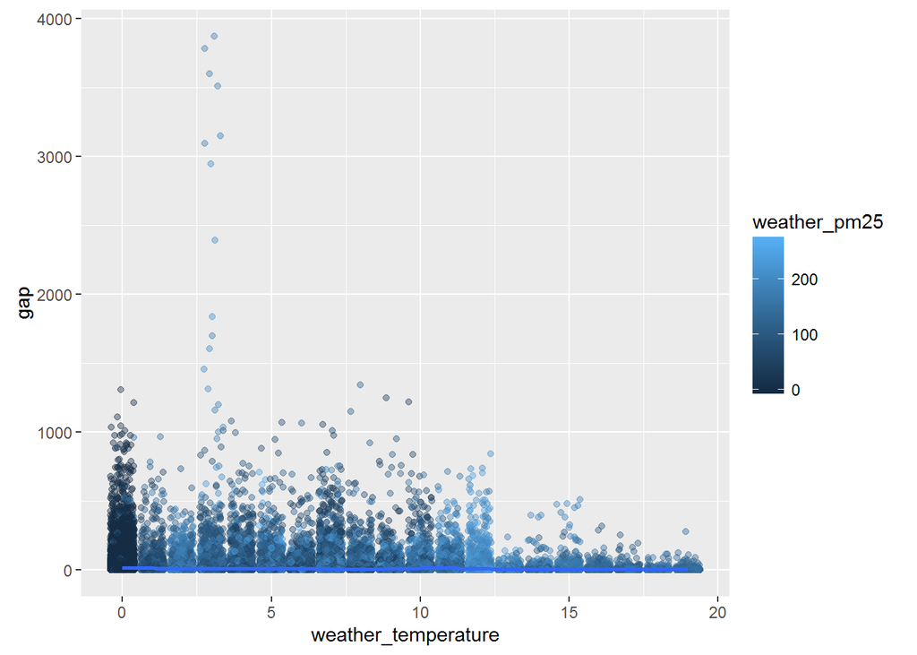